# Final Report for Red Wine Analysis

Ruiqiang Chen, Michael DeWitt, David Williams, Alex Vannoy

7/28/2017

# 1 Introduction

The purpose of this document is to report the proposed statistical models for classification of red wine bases on 11 predictors. The purpose of this analysis is to provide a model to the vintners in order for them to better predict the quality rating for their product. Analysis will be performing using both regression techniques and classification techniques.

# 2 Description of Data

The data set provided is the Wine dataset from UC Irvine of red vinho verde wine samples, from the north of Portugal [Cortez et al., 2009]. It consists of 1599 with a total of 11 physicochemical predictors and a response variable. These predictors include the following: fixed_acidity, volatile_acidity, citric_acid, residual_sugar, chlorides, free_sulfur_dioxide, total_sulfur_dioxide, density, pH, sulphates, alcohol, quality with the quality feature being associated with the judgement of the individual wine’s quality. Quality is the feature of interest for the dataset as the vintner is interested in judging the wine’s quality through objective means rather than today’s subjective method of averaging the 1-10 point judgment of taste-testers. A summary of these measures as well as the response variable can be seen in Table 1.

Summary Statistics for the Wine Dataset

| Descriptions | min | median | mean | max |
| --- | --- | --- | --- | --- |
| fixed acidity (g(tartaric acid)/dm^3) | 4.60 | 7.90 | 8.32 | 15.90 |
| volatile acidity (g(acetic acid)/dm^3) | 0.12 | 0.52 | 0.53 | 1.58 |
| citric acid (g/dm^3) | 0.00 | 0.26 | 0.27 | 1.00 |
| residual sugar (g/dm^3) | 0.90 | 2.20 | 2.54 | 15.50 |
| chlorides (g(sodium cloride)/dm^3 | 0.01 | 0.08 | 0.09 | 0.61 |
| free sulfur dioxide (mg/dm^3) | 1.00 | 14.00 | 15.87 | 72.00 |
| total sulfur dioxide (mg/dm^3) | 6.00 | 38.00 | 46.47 | 289.00 |
| density (g/cm^3) | 0.99 | 1.00 | 1.00 | 1.00 |
| pH | 2.74 | 3.31 | 3.31 | 4.01 |
| sulphates (g(potassium sulphate)/dm3) | 0.33 | 0.62 | 0.66 | 2.00 |
| alcohol (% vol.) | 8.40 | 10.20 | 10.42 | 14.90 |
| quality | 3.00 | 6.00 | 5.64 | 8.00 |

The distribution of these different criteria can be seen below in the histograms:

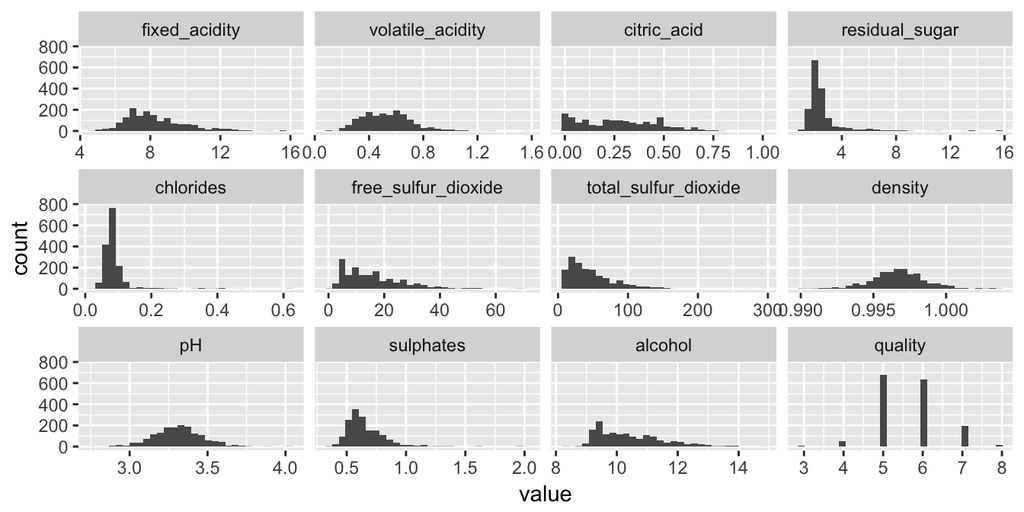

Histogram of all variables in the data set

The following are slightly right skewed: Fixed Acidity, Volatile Acidity, Citric Acid, , Free Sulfur Dioxide, Total Sulfur Dioxide, Sulphates, and Alcohol. Residual Sugar and Chlorides are heavily right skewed with density and pH appearing more normally distributed. Reviewing the individual components there appears to be a slight irregularity with total free sulfur dioxide. This can be seen in the histogram of this variable.

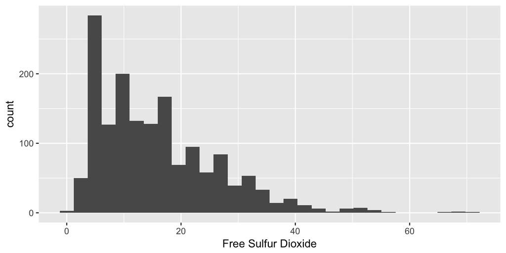

Histogram of Sulfur Dioxide Predictor

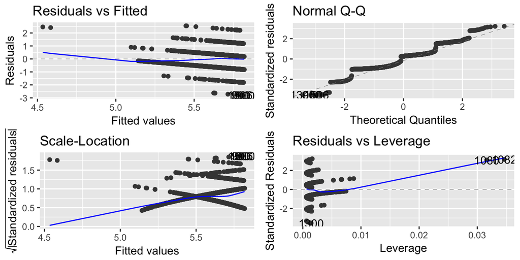

Residual Plots of Linear Model Predicting Quality with Total Sulfur Dioxide

These two wines have been removed from the clean dataset in order to be better predictors. The presence of these two wines may result in incorrect or inaccurate predictions. Ass we did not gather this dataset, we do not know if this information was incorrectly captured or if these values are real. However, given the strong indication that these two points are outliers with high leverage it is a good assumption to remove these two points.

# 3 Method

In order to understand the testing error of any of the modeling used the data was divided in testing and training data sets with which to train then models and then test and estimate the testing error. Seventy percent of the raw data was randomly selected and placed in the training set with the remaining 30% used in the testing data set.

## 3.1 Regression

In order to select the best fit regression model several different modeling methods were tested. These include Least Squares Regression, Ridge Regression, Lasso Regression, Principle Components Regression and Partial Least Squares Regression. For each of these methods the quality integer was the value that the model was attempting to predict. The data was divided into two sets, a training set to train the model and a testing set for model validation. We will now go deeper in the model generation process for each of these different modeling types and methods.

### 3.1.1 Least Squares

#### 3.1.1.1 Residual Analysis

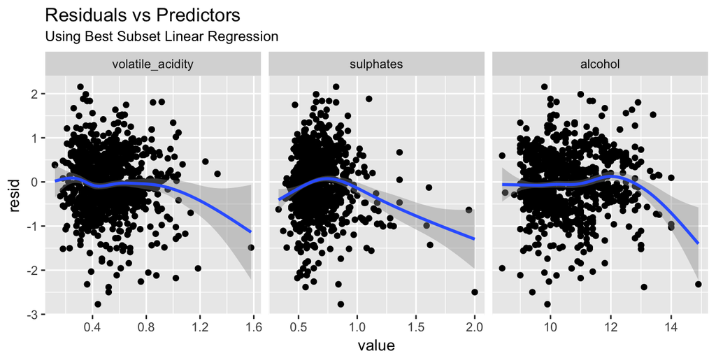

Plot of Residuals from Linear Regression

The residuals appear to have no distinct pattern which is a positive sign that there are not lurking relationships that have not been treated by the modeling.

### 3.1.2 Ridge Regression

Ridge regression was performed on the dataset as well. Cross validation was performed on the training data set to determine the optimum value for lambda for the ridge regression. This lambda, 0.079 was then using in a ridge regression model with the testing dataset.

### 3.1.3 Lasso Regression

Lasso regression was used with cross validation on the data set. Cross validation was used to determine the best lambda which was 0.005. As a function of the lasso regression only pH was shrunk to zero with total sulphur dioxide and free sulphur dioxide being shrunk to near zero.

### 3.1.4 Principal Components Regression

Principal components regression was used. Based on the analysis of the principal components, the first nine principal components were used to be trained on the training set. This was done because 90% of the variation could be explained by these first nine components.

### 3.1.5 Partial Least Squares Regression

This was used. Difference is that it uses quality response as supervision over the principal components.

### 3.1.6 Boosted Regression

Boosted regression also used. The interaction depth was limited to four in order to not over-fit the data. The model was trained on 5,000 different trees.

### 3.1.7 Model Selection

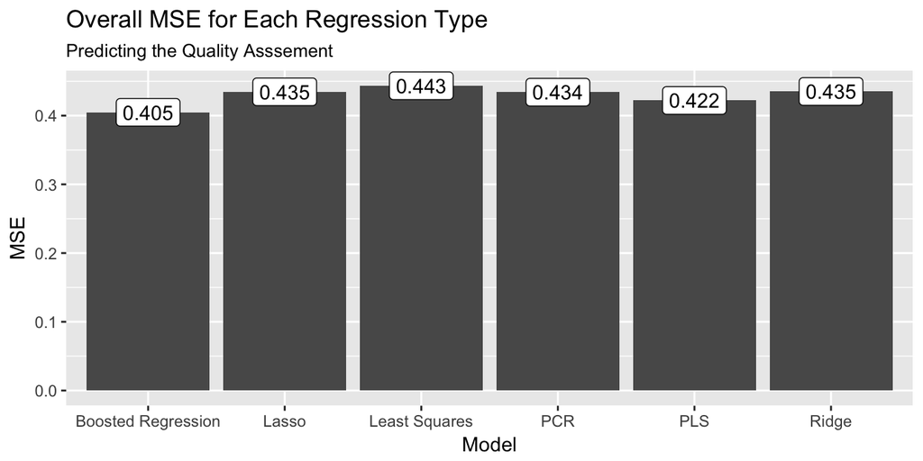

Plot of Results of Different Regression Techniques

## 3.2 Classification

For classification purposes the wines were segregated in to three different classes. These classes include “good” ($quality >7$), “medium” ($\; quality \; between \; 4 \;and\; 7$) and “poor”($quality < 4$).

### 3.2.1 Model Selection

Several different classification models were used in this analysis given the new variable added to the data set. The methods used were K-Nearest Neighbours, Linear Discriminate Analysis, Quadratic Discriminate Analysis and tree classification. These different models were trained on the training data set and then applied to the testing dataset to understand the accuracy. It is important to note that greater accuracy was achieved scaling values for the K-Nearest Neighbours approach as this approach using Euclidean distances and thus is sensitive to scale differences. The phenomena can be seen as with the unscaled values the validation algorithm found that 17 were used versus 64. The larger number of neighbours makes for a much more global model, less sensitive to immediate neighbours in the bias versus variance trade off. The tree classification model was trained first through cross validation and then pruned to six leaves in order to reduce the impact of over-fitting in the bias variance trade off.

## 3.3 Comparison of Models

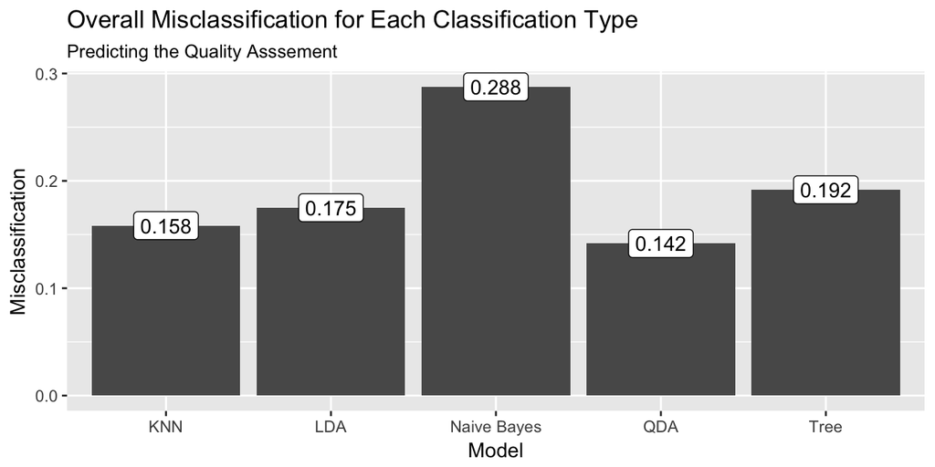

Plot of Results of Different Classification Techniques

All of these models seek to maximize the global accuracy of the model. More interesting for the vintners is the ability to detect each of the three different classes of the wines.

Detailed Classification Accuracy

| Method | Good | Medium | Poor |
| --- | --- | --- | --- |
| KNN | 0.24 | 0.98 | 0.00 |
| Naive Bayes | 0.52 | 0.77 | 0.06 |
| LDA | 0.43 | 0.93 | 0.06 |
| QDA | 0.61 | 0.90 | 0.89 |
| Tree | 0.36 | 0.92 | 0.00 |

# 4 Discussion

# 5 Conclusion

Turning to the classification method, the best overall classification method was Quadratic Discriminate Analysis. This is seen in both the overall accuracy as well in its ability to accurately classify each subcategory. While the other methods had poorer abilities to detect the good and poor wines, the QDA method showed the best accuracy in these two fields, which is very important for vintners when it comes to pricing and selling. The penalty of misclassifying a good wine as medium or a poor wine as medium/ good is severe as this may damage the reputation of the winery. From this analysis it is clear that QDA is the superior method for classification of red wines given this dataset.

# 6 Issues